# Virtual Reality Interventions: Evaluating Efficacy in the Treatment of GAD

Alan Kinsella, Erik Trujillo

13/12/2023

## Table of Contents

1. Abstract
2. Introduction
3. Method
   - Initial Inspection
   - Data Cleanup
4. Results
5. Discussion
6. References

## Abstract

This study investigates the efficacy of Virtual Reality (VR) as a therapeutic tool and compares it to traditional Cognitive Behavioral Therapy (CBT). Through an experiment, participants were assigned to either VR therapy (experimental group) or traditional CBT (control group) and their GAD and State-Trait Anxiety Inventory (STAI) scores were assessed pre and post-treatment. Our statistical analysis focuses on comparing these scores to evaluate therapy effectiveness.

## Introduction

This study will look at the results of an experiment comparing GAD and STAI scores of patients treated using traditional CBT (Control Group) and VR Therapy (Experimental Group) to identify the degree to which VR therapy has an effect compartive to proven therapy techniques.

## Method

### Initial Inspection

Initial inspection shows the same data types on both datasets. Patients are categorized by gender, and there are numeric scores for Generalized Anxiety Disorder (GAD) and State-Trait Anxiety Inventory (STAI). We have results both for pre-trial testing and post trial testing.

Our preliminary analysis shows consistency in data types and formats. The summary is showing some insight on how the data is distributed, which may indicate initial differences between both treatments. There are also some outliers visible within the minimum values that might need to be looked at during our cleaning process. We need to first understand if negative values are possible in this type of results and if they could skew our results to the wrong conclusions.

#### Summary of Control Group

```
##    patientID        gender           pretrial_GAD   pretrial_STAI
##  Min.   : 1.00   Length:90          Min.   : 8.00   Min.   :49.00
##  1st Qu.:23.25   Class :character   1st Qu.:12.00   1st Qu.:57.00
##  Median :45.50   Mode  :character   Median :14.00   Median :60.00
##  Mean   :45.50                      Mean   :14.02   Mean   :60.19
##  3rd Qu.:67.75                      3rd Qu.:16.00   3rd Qu.:64.00
##  Max.   :90.00                      Max.   :20.00   Max.   :71.00
##  posttrial_GAD   posttrial_STAI
##  Min.   : 6.00   Min.   :-62.00
##  1st Qu.:12.00   1st Qu.: 56.25
##  Median :14.00   Median : 61.00
##  Mean   :13.64   Mean   : 60.24
##  3rd Qu.:16.00   3rd Qu.: 66.00
##  Max.   :21.00   Max.   :111.00
```

#### Summary of Experimental Group

```
##    patientID        gender           pretrial_GAD   pretrial_STAI
##  Min.   : 1.00   Length:90          Min.   :12.00   Min.   :-59.00
##  1st Qu.:23.25   Class :character   1st Qu.:15.00   1st Qu.: 57.00
##  Median :45.50   Mode  :character   Median :16.00   Median : 61.00
##  Mean   :45.50                      Mean   :15.88   Mean   : 59.43
##  3rd Qu.:67.75                      3rd Qu.:17.00   3rd Qu.: 64.00
##  Max.   :90.00                      Max.   :20.00   Max.   : 74.00
##  posttrial_GAD  posttrial_STAI
##  Min.   : 8.0   Min.   :44.00
##  1st Qu.:12.0   1st Qu.:52.00
##  Median :14.0   Median :56.00
##  Mean   :13.9   Mean   :57.82
##  3rd Qu.:16.0   3rd Qu.:63.00
##  Max.   :19.0   Max.   :93.00
```

### Data Cleanup

During the data cleanup stage, we found 0 missing values in the control group and 0 missing values in the experimental group meaning no participants need to be removed for lack of data.We then verified the data types, ensuring that patient IDs were treated as character strings to avoid any numerical interpretation in our analyses, and that test results were appropriately handled as numeric values. This step was essential for accurate statistical computations.

#### Filtering values outside of test boundaries

A key part of our cleanup involved filtering out test scores outside the boundaries for GAD (0-21) and STAI (20-80). This was necessary, as scores outside these ranges would not be considered clinically meaningful and could be attributed to typing error. After applying these filters, we reassessed the data to confirm that no outliers remained, which is clear in the summary minimum and maximum values. See references for sources on test boundaries

Post-cleanup, our datasets present a more accurate reflection of the experiment results. Both control and experimental groups show data consistency, with no invalid values, and remained well distributed within the expected score ranges.This is a solid foundation for us to formulate our hypothesis.

#### Summary of Control Group After Cleanup

```
##   patientID            gender           pretrial_GAD   pretrial_STAI
##  Length:88          Length:88          Min.   : 8.00   Min.   :49.00
##  Class :character   Class :character   1st Qu.:12.00   1st Qu.:57.00
##  Mode  :character   Mode  :character   Median :14.00   Median :60.00
##                                        Mean   :13.99   Mean   :60.12
##                                        3rd Qu.:16.00   3rd Qu.:64.00
##                                        Max.   :20.00   Max.   :71.00
##  posttrial_GAD   posttrial_STAI
##  Min.   : 6.00   Min.   :47.00
##  1st Qu.:11.75   1st Qu.:56.75
##  Median :14.00   Median :61.00
##  Mean   :13.59   Mean   :61.06
##  3rd Qu.:16.00   3rd Qu.:66.00
##  Max.   :21.00   Max.   :75.00
```

#### Summary of Experimental Group After Cleanup

```
##   patientID            gender           pretrial_GAD   pretrial_STAI
##  Length:88          Length:88          Min.   :12.00   Min.   :49.00
##  Class :character   Class :character   1st Qu.:15.00   1st Qu.:57.75
##  Mode  :character   Mode  :character   Median :16.00   Median :61.00
##                                        Mean   :15.88   Mean   :60.81
##                                        3rd Qu.:17.00   3rd Qu.:64.25
##                                        Max.   :20.00   Max.   :74.00
##  posttrial_GAD   posttrial_STAI
##  Min.   : 8.00   Min.   :44.00
##  1st Qu.:12.00   1st Qu.:52.00
##  Median :14.00   Median :56.00
##  Mean   :13.88   Mean   :57.49
##  3rd Qu.:16.00   3rd Qu.:63.00
##  Max.   :19.00   Max.   :69.00
```

#### Hypothesis Formulation

After our initial inspection, we compared the difference between means of pre-trial and post-trial scores for both GAD and STAI results. Our observations have led us to the following hypotheses:

- **Null Hypothesis (H0):** VR-based therapy does not have a significant difference in effectiveness from traditional CBT therapy in treating Generalized Anxiety Disorder (GAD).
- **Alternative Hypothesis (H1):** VR-based therapy is significantly more effective than traditional CBT therapy to threat Generalized Anxiety Disorder (GAD).

The validation of these hypotheses will be done through a statistical analysis of GAD and STAI scores from both the control (CBT) and experimental (VR) groups.

#### Visual Inspection for Normality

In order to determine the kind of testing we will run for our hypotheses, we will first review our datasets more in depth and determine if they are normally distributed or not.To begin, we will do a visual inspection using Box Plots, histograms, density plots and QQ plots.

#### Visualization of GAD results for pre-trial and post-trial groups

The boxplots provide an initial visual indication of the data’s distribution. In the control group, the boxplot reveals a slight asymmetry in post-trial GAD scores, suggesting potential skewness. Comparatively, the experimental group’s boxplots shows a more symmetric distribution, aligning closer with normality.

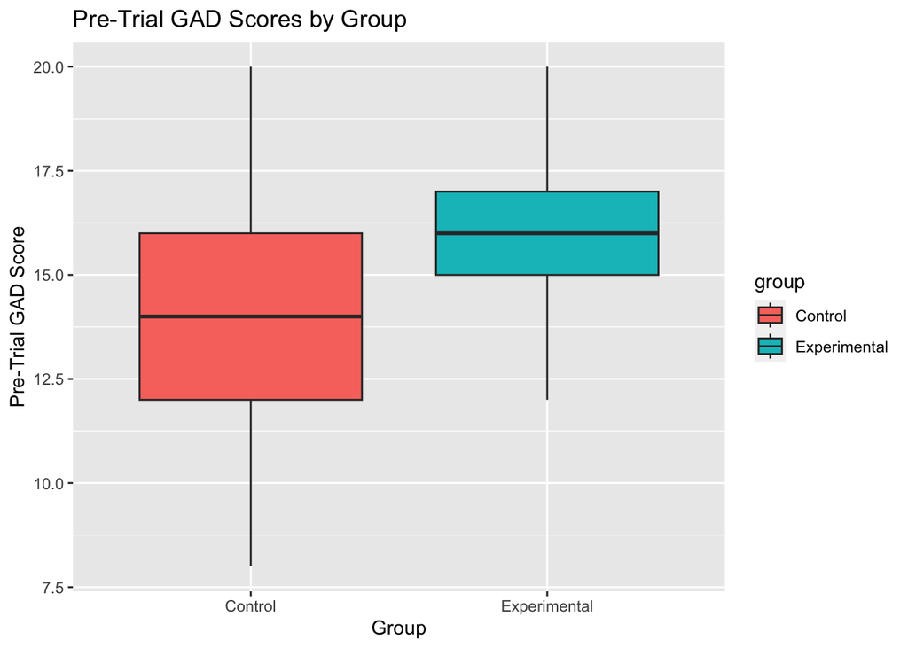

```
Control Pre Trial mean GAD score:  13.98864
```

```
Experimental Pre Trial mean GAD score:
15.875
```

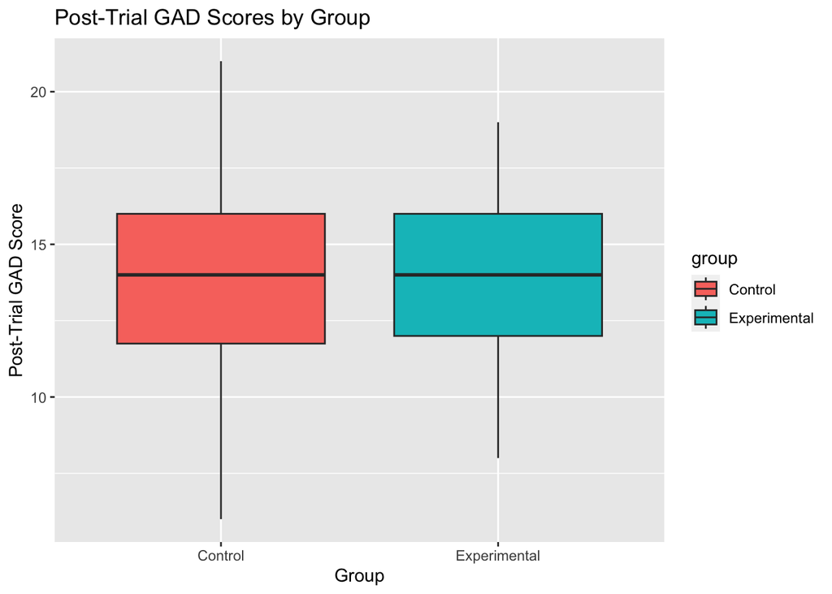

```
Control Post Trial mean GAD score:  13.59091
```

```
Experimental Post Trial mean GAD score:
13.875
```

In this joint histograms and density plots we can look for the distribution curves of our data. The control group’s pre-trial GAD scores exhibit a bell-shaped curve but with noticeable deviations, hinting at a non-normal distribution; the same can be said of the Experimental group’s post-trial results. In contrast, the experimental group’s pre-trial GAD scores display a more uniform bell shape, suggesting normality. The varying peak heights and spread of the histograms across different test scores highlight the diverse response patterns between the two groups.

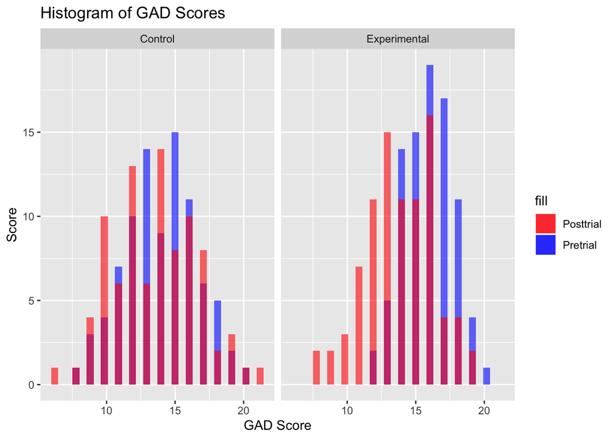

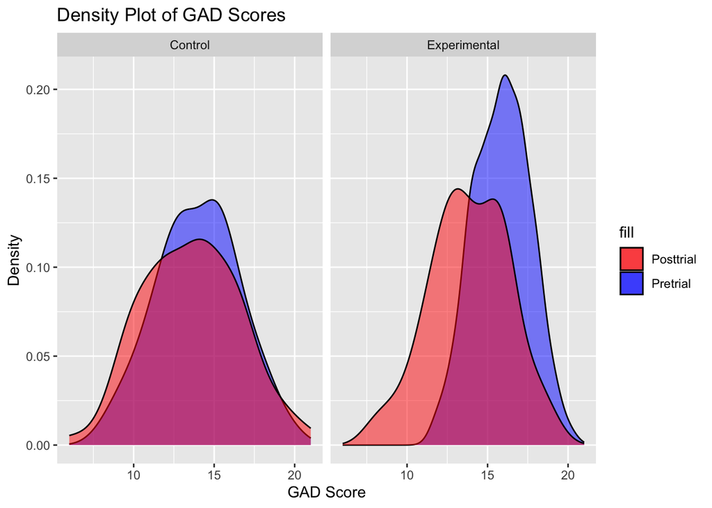

The QQ plots for both groups reveal a normal tendency of the central data and showcase some clear but small number of outliers. Control group’s pre-trial GAD results and Experimental group’s post-trial results show the most distance from the projected line of normality at both tails.

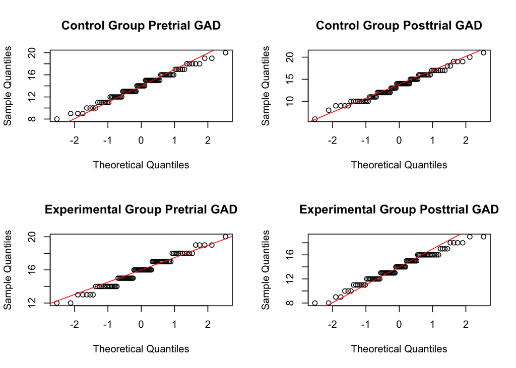

#### Visualization of STAI results for pre-trial and post-trial groups

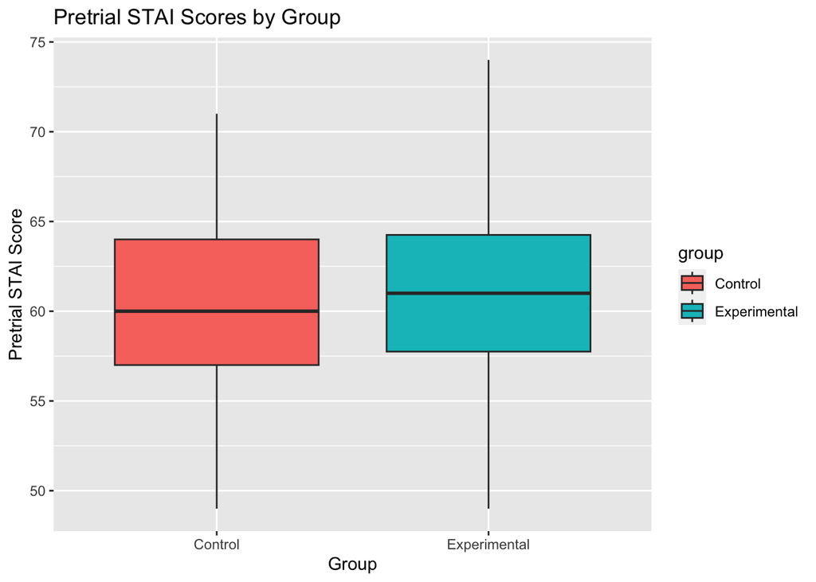

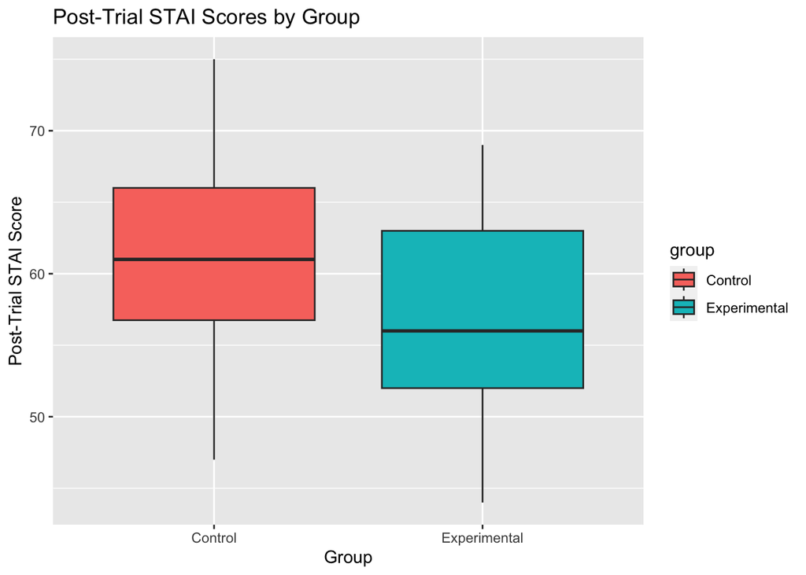

```
## Control Pre Trial mean STAI score:  60.125
```

```
## Experimental Pre Trial mean STAI score:
## 60.80682
```

The control group’s pre-trial and post-trial STAI scores exhibit a bell-shaped curve with only slight deviations, hinting at normality. In contrast, pre-trial and post-trial results for the experimental group display a less uniform bell shape, suggesting the opposite. The varying peak heights are much more subtle than in the GAD scores.

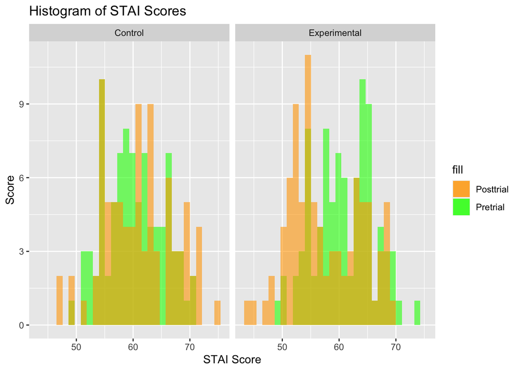

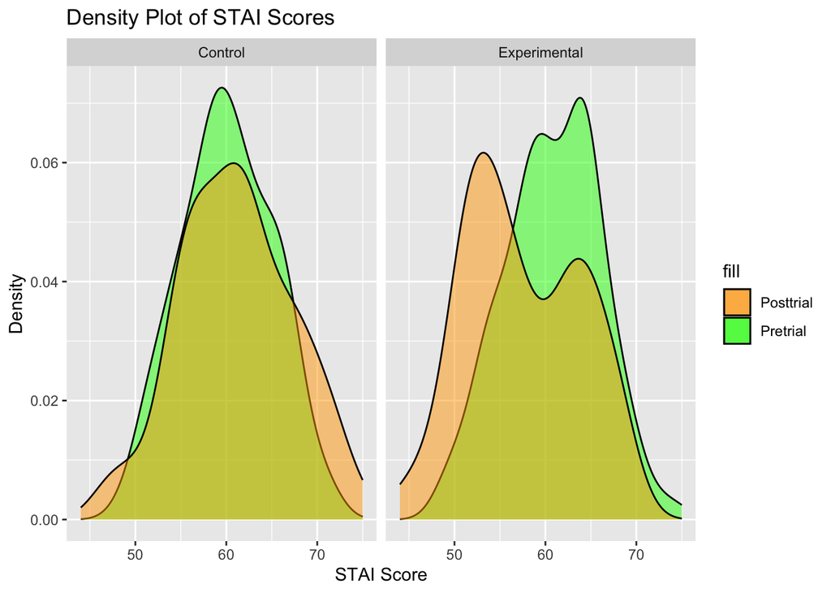

As with the GAD scores, the STAI score’s QQ plots for both testing methods reveal what seems a normal tendency of the central data and showcase some clear but small number of outliers. The only group that seems to deviate the most is the Experimental group for its post-trial results.

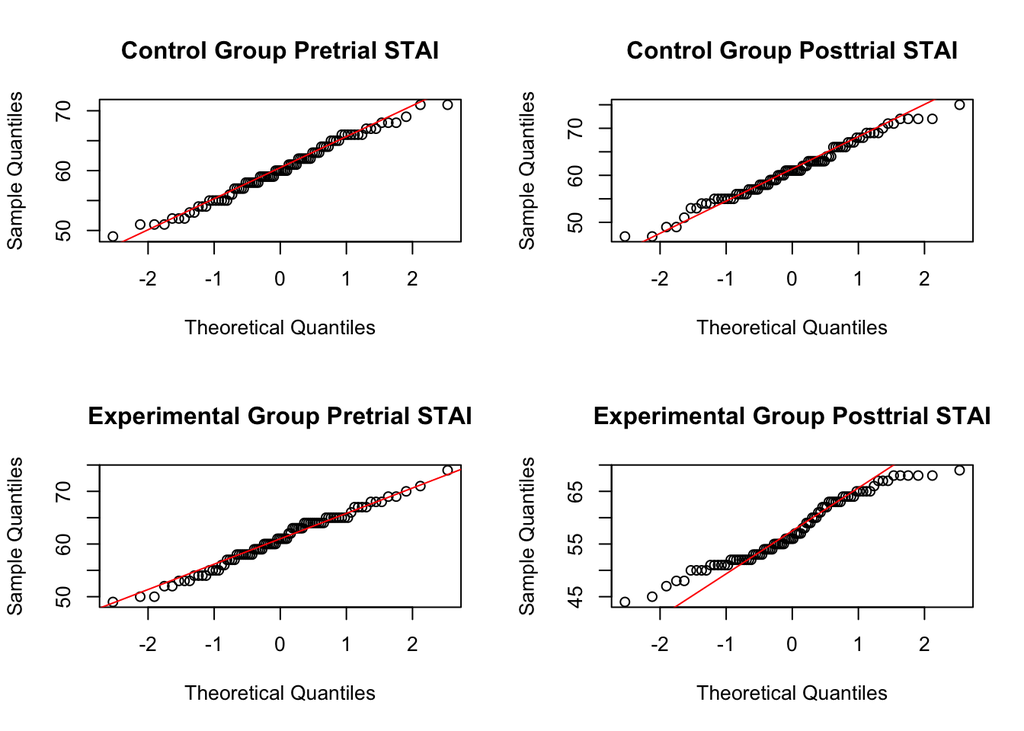

#### Testing for Normality

##### Anderson-Darling Test

- From the output obtained we can assume normality as the p-value of 0.0917 is greater than 0.05 for data: control_group_cleaned$pretrial_GAD
- From the output obtained we can assume normality as the p-value of 0.0811 is greater than 0.05 for data: control_group_cleaned$posttrial_GAD
- From the output obtained we can assume normality as the p-value of 0.4576 is greater than 0.05 for data: control_group_cleaned$pretrial_STAI
- From the output obtained we can assume normality as the p-value of 0.3668 is greater than 0.05 for data: control_group_cleaned$posttrial_STAI

##### Shapiro-Wilk Test

- From the output obtained we can assume normality as the p-value of 0.2959 is greater than 0.05 for data: control_group_cleaned$pretrial_GAD
- From the output obtained we can assume normality as the p-value of 0.3067 is greater than 0.05 for data: control_group_cleaned$posttrial_GAD
- From the output obtained we can assume normality as the p-value of 0.4386 is greater than 0.05 for data: control_group_cleaned$pretrial_STAI
- From the output obtained we can assume normality as the p-value of 0.4281 is greater than 0.05 for data: control_group_cleaned$posttrial_STAI

### Hypothesis testings

```
##
##  Welch Two Sample t-test
##
## data:  control_group_results and experimental_group_results
## t = 6.6305, df = 172.26, p-value = 4.143e-10
## alternative hypothesis: true difference in means is not equal to 0
## 95 percent confidence interval:
##  1.125291 2.079254
## sample estimates:
##  mean of x  mean of y
## -0.3977273 -2.0000000
```

```
##
##  Welch Two Sample t-test
##
## data:  control_group_results_STAI and experimental_group_results_STAI
## t = 8.102, df = 173.44, p-value = 9.28e-14
## alternative hypothesis: true difference in means is not equal to 0
## 95 percent confidence interval:
##  3.214649 5.285351
## sample estimates:
##  mean of x  mean of y
##  0.9318182 -3.3181818
```

### Discussion

Our analysis, utilizing Welch’s Two Sample t-tests, revealed a statistically significant difference in treatment effectiveness between the control group (CBT) and the experimental group (VR therapy) for both GAD (Generalized Anxiety Disorder) and STAI (State-Trait Anxiety Inventory) scores.

For GAD scores, the p-value obtained was approximately 4.143e-10, which indicates an extremely low probability of observing the same difference by chance. This p-value strongly refutes the null hypothesis (H0) that VR-based therapy has no significant difference in effectiveness compared to traditional CBT therapy for GAD. The negative mean change in both groups reflects a decrease in GAD scores post-treatment, with the experimental group demonstrating a more substantial reduction.

Similarly, for STAI scores, the p-value obtained was approximately 9.28e-14, once again emphasizing a very low likelihood of obtaining these results by chance. This p-value also rejects the null hypothesis (H0) that there is no difference in effectiveness between the two treatment methods for reducing anxiety levels. The negative mean change in the experimental group indicates a reduction in anxiety levels, contrasting with the control group, where a negative value was not reached.

In summary, both extremely low p-values provide strong evidence that VR-based therapy is significantly more effective than traditional CBT therapy in reducing symptoms of Generalized Anxiety disorder.

### References

- State and Trait Anxiety Scores of Patients Receiving Intravitreal Injections, NCBI, 2017. https://www.ncbi.nlm.nih.gov/pmc/articles/PMC6945947/ [Accessed 19 Dec. 2023].
- CORC. (2023). Generalised Anxiety Disorder Assessment (GAD-7). [online] Available at: https://www.corc.uk.net/outcome-experience-measures/generalised-anxiety-disorder-assessment-gad-7 [Accessed 19 Dec. 2023].
- RStudio. (2023). R Markdown Quick Tour. [online] Available at: https://rmarkdown.rstudio.com/authoring_quick_tour.html [Accessed 19 Dec. 2023].
- Martin, G. (2023). Clean your data with R. R programming for beginners. [video] Available at: https://www.youtube.com/watch?v=sV5lwAJ7vnQ [Accessed 19 Dec. 2023].
- McGuinness, N. (2023). 2023_MSC_DataAnalytics_IntroToR/Examples/9_TestingForNormality.R. [online] GitHub. Available at: https://github.com/nmcguinness/2023_MSC_DataAnalytics_IntroToR/blob/main/Examples/9_TestingForNormality.R [Accessed 19 Dec. 2023].
- “12.5 The anatomy of a Notebook / R Markdown file.” In R for Health Data Science. [online] Available at: https://argoshare.is.ed.ac.uk/healthyr_book/the-anatomy-of-a-notebook-r-markdown-file.html [Accessed 19 Dec. 2023].
- Statistics Solutions. (2023). Paired Sample T-Test. [online] Available at: https://www.statisticssolutions.com/free-resources/directory-of-statistical-analyses/paired-sample-t-test/ [Accessed 19 Dec. 2023].
- STHDA. (2023). ggplot2 box plot: Quick start guide - R software and data visualization. [online] Available at: http://www.sthda.com/english/wiki/ggplot2-box-plot-quick-start-guide-r-software-and-data-visualization [Accessed 19 Dec. 2023].